# TL-20-920D6D SYGNOMICS Report

01/09/2022

|  | Patient ID | Age | Sex | MGMT Methylation | ExomeSeq | RNASeq | CNV | Profiling Type |
| --- | --- | --- | --- | --- | --- | --- | --- | --- |
| 1 | TL-20-920D6D |  |  | Methylated | Yes | Yes | Yes | Unknown |

# SOC Drugs

# 1. Target: GSR

### Drugs

|  | Drug | Drug Action | Toxicity Class | Max GBM Phase | FDA Approved | Clinical Trials |
| --- | --- | --- | --- | --- | --- | --- |
| 1 | CARMUSTINE | INHIBITOR |  | 4 | TRUE | Clinical Trials |

### Model Evidence

**6** regulons containing the target(s), **GSR** are overactive in this patient.

### Hallmarks Enrichment

None

### Literature Evidence

|  | Gene | Evidence | Disease | Title | PMID | Year | Type |
| --- | --- | --- | --- | --- | --- | --- | --- |
| 1 | GSR | Carmustine implantation in resection cavity provides survival benefit for GBM patients, and it may be a promising supplement to standard therapeutic protocol by offering a bridge between surgical rese… | GBM | Carmustine as a Supplementary Therapeutic Option for Glioblastoma: A Systematic Review and Meta-Analysis | 33041980 | 2020 | Publication |
| 2 | GSR | The expression of glutathione reductase (GSR), was higher in TMZ-resistant cells than in sensitive cells. Silencing GSR in drug-resistant cells improved the sensitivity of cells to TMZ or cisplatin. | GBM | Glutathione reductase mediates drug resistance in glioblastoma cells by regulating redox homeostasis | 29105080 | 2018 | Publication |
| 3 | GSR | We showed that upon TMZ treatment there is an induction of the nuclear factor erythroid 2-related factor 2 (NRF2), which is the main antioxidant transcription factor regulator in human cells. This is … | GBM | NRF2 and glutathione are key resistance mediators to temozolomide in glioma and melanoma cells | 27344172 | 2016 | Publication |
| 4 | GSR | The present disclosure teaches that glioma cells are dependent on system Xc for cystine uptake. Pharmacological inhibition of system Xc causes a rapid depletion of intracellular glutathione, resulting… | GBM | Method for treating glioma | WO2006049957A2 | 2005 | Patent |

### Glioblastoma Clinical Trials

|  | NCT.Number | Title | Status | Interventions | Phases | First.Posted |
| --- | --- | --- | --- | --- | --- | --- |
| 1 | NCT04421378 | A Study of Selinexor in Combination With Standard of Care Therapy for Newly Diagnosed or Recurrent Glioblastoma | Recruiting | Drug: Selinexor\|Drug: Temozolomide (TMZ)\|Drug: Lomustine (CCNU)\|Radiation: Standard Fractionated Radiation therapy (RT)\|Drug: Bevacizumab\|Device: TTField\|Drug: Carmustine | Phase 1\|Phase 2 | 9-Jun-20 |
| 2 | NCT00068952 | Study of IV Edotecarin Vs Temozolomide or Carmustine (BCNU) or Lomustine (CCNU) in Patients With Glioblastoma Multiforme | Completed | Drug: Edotecarin\|Drug: Temozolomide\|Drug: Carmustine (BCNU)\|Drug: Lomustine (CCNU) | Phase 3 | 16-Sep-03 |
| 3 | NCT00076986 | The PRECISE Trial: Study of IL13-PE38QQR Compared to GLIADEL Wafer in Patients With Recurrent Glioblastoma Multiforme | Completed | Drug: IL13-PE38QQR\|Procedure: surgery and catheter placement (2 procedures)\|Drug: prolifespan 20 with carmustine implant (GLIADEL® Wafer)\|Procedure: surgery and wafer placement (1 procedure) | Phase 3 | 10-Feb-04 |
| 4 | NCT00761280 | Efficacy and Safety of AP 12009 in Patients With Recurrent or Refractory Anaplastic Astrocytoma or Secondary Glioblastoma | Terminated | Drug: trabedersen\|Drug: temozolomide\|Device: Drug delivery system for administration of AP 12009\|Procedure: Placement of Drug Delivery System\|Drug: carmustine\|Drug: lomustine | Phase 3 | 29-Sep-08 |
| 5 | NCT02348255 | NovoTTF-100A With Bevacizumab and Carmustine in Treating Patients With Glioblastoma Multiforme in First Relapse | Withdrawn | Procedure: Electric Field Therapy\|Biological: Bevacizumab\|Drug: Carmustine\|Other: Quality-of-Life Assessment | Phase 2 | 28-Jan-15 |
| 6 | NCT05052957 | hSTAR GBM (Hematopoetic Stem Cell (HPC) Rescue for GBM) | Not yet recruiting | Biological: P140K-MGMT\|Drug: O6-benzylguanine\|Radiation: Photon Based Radiotherapy\|Drug: temozolomide\|Drug: Filgrastim\|Drug: carmustine | Phase 2 | 22-Sep-21 |
| 7 | NCT00814593 | Lymphokine-Activated Killer Cells or Gliadel Wafer in Treating Patients With Newly Diagnosed Glioblastoma Multiforme That Can Be Removed by Surgery | Withdrawn | Biological: lymphokine-activated killer cells\|Drug: polifeprosan 20 with carmustine implant | Phase 2 | 25-Dec-08 |
| 8 | NCT00027612 | Irinotecan Plus Radiation Therapy Followed By Chemotherapy in Treating Patients With Glioblastoma Multiforme | Completed | Drug: carmustine\|Drug: irinotecan hydrochloride\|Radiation: radiation therapy | Phase 1\|Phase 2 | 17-Jun-03 |
| 9 | NCT00002545 | Radiation Therapy Plus Chemotherapy in Treating Patients With Supratentorial Glioblastoma Multiforme | Completed | Drug: carmustine\|Radiation: low-LET photon therapy | Phase 3 | 19-Jul-04 |
| 10 | NCT00003417 | Computer Planned Radiation Therapy Plus Chemotherapy in Treating Patients With Glioblastoma Multiforme | Completed | Drug: carmustine\|Radiation: radiation therapy | Phase 1\|Phase 2 | 27-Jan-03 |

[output cut: 26 more lines]

### Network Plots

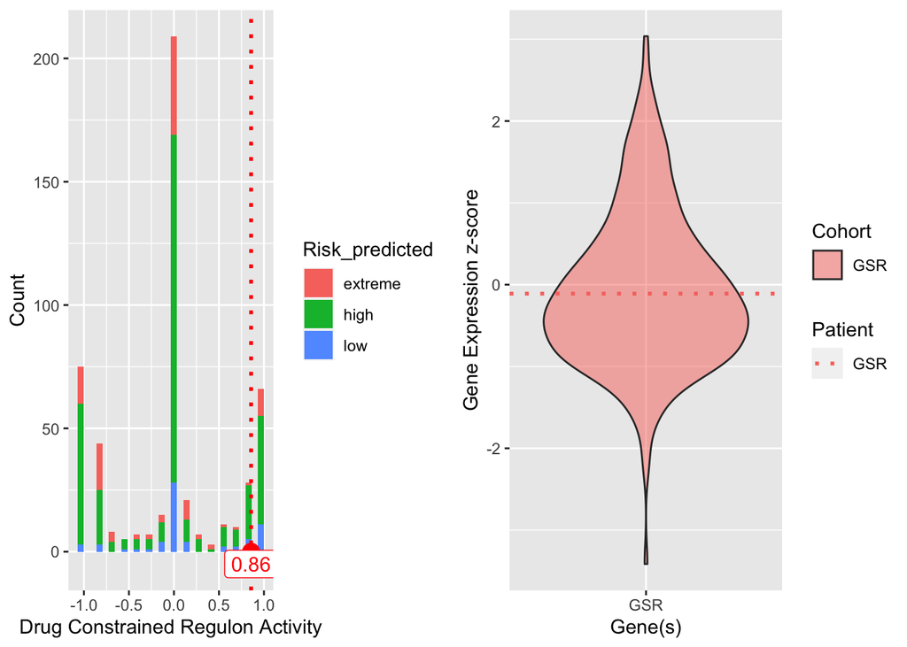

# Drugs in GBM Trials

# 1. Target: RRM2

### Drugs

|  | Drug | Drug Action | Toxicity Class | Max GBM Phase | FDA Approved | Clinical Trials |
| --- | --- | --- | --- | --- | --- | --- |
| 1 | HYDROXYUREA | INHIBITOR | Carcinogenicity Hematological toxicity | 3 | TRUE | Clinical Trials |

### Model Evidence

**12** regulons containing the target(s), **RRM2** are overactive in this patient.

### Hallmarks Enrichment

None

### Literature Evidence

|  | Gene | Evidence | Disease | Title | PMID | Year | Type |
| --- | --- | --- | --- | --- | --- | --- | --- |
| 1 | RRM2 | These findings indicated that RRM2 is a positive regulator of glioma progression which contributes to the migration and proliferation of glioma cells through ERK1/2 and AKT signalings and might be a n… | GBM | RRM2 is a potential prognostic biomarker with functional significance in glioma | 30745840 | 2019 | Publication |
| 2 | RRM2 | we show that treatment with a RRM2 inhibitor triapine reproduces the BRCA1-depletion GBM-repressive phenotypes and sensitizes GBM cells to PARP inhibition. We propose that GBM cells are addicted to th… | GBM | BRCA1-regulated RRM2 expression protects glioblastoma cells from endogenous replication stress and promotes tumorigenicity | 27845331 | 2016 | Publication |
| 3 | RRM2 | GBM cells were shown to rely on RRM2 during therapy causing RRM2-knockdown (KD) cells to be TMZ-sensitive.Ê | GBM | Ribonucleotide Reductase Regulatory Subunit M2 as a Driver of Glioblastoma TMZ-Resistance through Modulation of dNTP Production | 10.1101/2021.11.23.469785 | 2021 | Preprint |

### Glioblastoma Clinical Trials

|  | NCT.Number | Title | Status | Interventions | Phases | First.Posted |
| --- | --- | --- | --- | --- | --- | --- |
| 1 | NCT00290771 | Efficacy and Safety of Imatinib Mesylate Plus Hydroxyurea (HU) in Patients With Recurrent Glioblastoma Multiforme (GBM) | Terminated | Drug: Imatinib tablets\|Drug: Hydroxyurea capsules | Phase 2 | 13-Feb-06 |
| 2 | NCT03463733 | Hydroxy-urea and Temozolomide in Patients With a Recurrent Malignant Brain Tumor (Glioblastoma) | Recruiting | Drug: Hydroxyurea\|Drug: Temozolomide | Phase 1 | 13-Mar-18 |
| 3 | NCT00154375 | Study of Imatinib Mesylate in Combination With Hydroxyurea Versus Hydroxyurea Alone as an Oral Therapy in Patients With Temozolomide Resistant Progressive Glioblastoma | Completed | Drug: Imatinib mesylate\|Drug: Hydroxyurea | Phase 3 | 12-Sep-05 |
| 4 | NCT00019058 | Radiation Therapy in Treating Patients With Glioblastoma | Completed | Drug: chemotherapy\|Drug: hydroxyurea\|Drug: pentoxifylline\|Radiation: radiation therapy | Phase 1 | 5-Apr-04 |
| 5 | NCT00615927 | Phase II Imatinib + Hydroxyurea in Treatment of Patients With Recurrent/Progressive Grade II Low-Grade Glioma (LGG) | Completed | Drug: Imatinib Mesylate & Hydroxyurea | Phase 2 | 14-Feb-08 |
| 6 | NCT00613132 | Ph I Gleevec in Combo w RAD001 + Hydroxyurea for Pts w Recurrent MG | Completed | Drug: Gleevec, RAD001, and Hydroxyurea | Phase 1 | 12-Feb-08 |
| 7 | NCT00613054 | Ph I Zactima + Imatinib Mesylate & Hydroxyurea for Pts w Recurrent Malignant Glioma | Completed | Drug: Zactima, Gleevec, Hydroxyurea | Phase 1 | 12-Feb-08 |
| 8 | NCT00354913 | Imatinib Mesylate and Hydroxyurea in Treating Patients With Recurrent or Progressive Meningioma | Completed | Drug: hydroxyurea\|Drug: imatinib mesylate | Phase 2 | 20-Jul-06 |
| 9 | NCT00387933 | Imatinib Mesylate, Vatalanib, and Hydroxyurea in Treating Patients With Recurrent or Relapsed Malignant Glioma | Completed | Drug: hydroxyurea\|Drug: imatinib mesylate\|Drug: vatalanib | Phase 1 | 13-Oct-06 |

### Network Plots

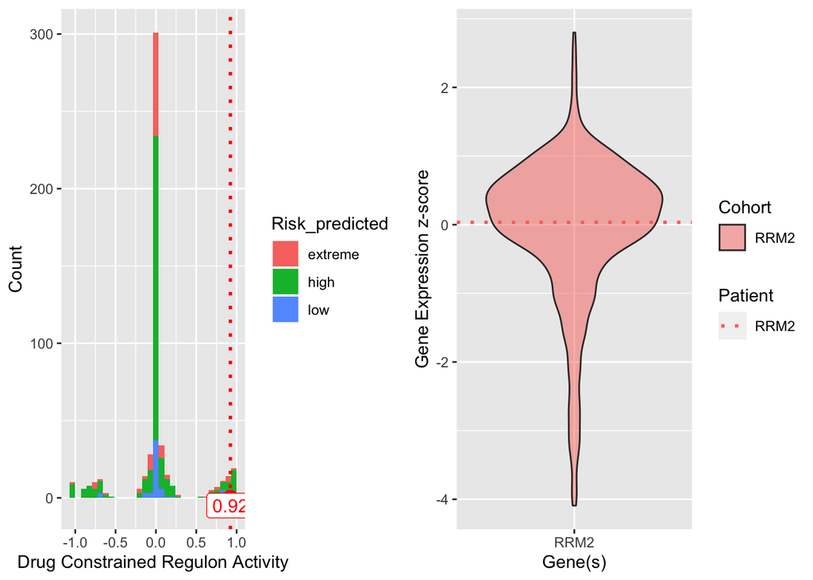

# FDA Approved Drugs

# 1. Target: MAOB

### Drugs

|  | Drug | Drug Action | Toxicity Class | Max GBM Phase | FDA Approved | Clinical Trials |
| --- | --- | --- | --- | --- | --- | --- |
| 1 | RASAGILINE | INHIBITOR |  | 0 | TRUE | Clinical Trials |
| 2 | SELEGILINE HYDROCHLORIDE | INHIBITOR |  | 0 | TRUE | Clinical Trials |
| 3 | SELEGILINE | INHIBITOR | Psychiatric toxicity | 0 | TRUE | Clinical Trials |
| 4 | SAFINAMIDE MESYLATE | INHIBITOR |  | 0 | TRUE | Clinical Trials |
| 5 | RASAGILINE MESYLATE | INHIBITOR |  | 0 | TRUE | Clinical Trials |
| 6 | SAFINAMIDE | INHIBITOR |  | 0 | TRUE | Clinical Trials |

### Model Evidence

**3** regulons containing the target(s), **MAOB** are overactive in this patient.

### Hallmarks Enrichment

None

### Literature Evidence

No additional evidence was found

### Glioblastoma Clinical Trials

No glioblastoma clinical trials were found for these drugs.

### Network Plots

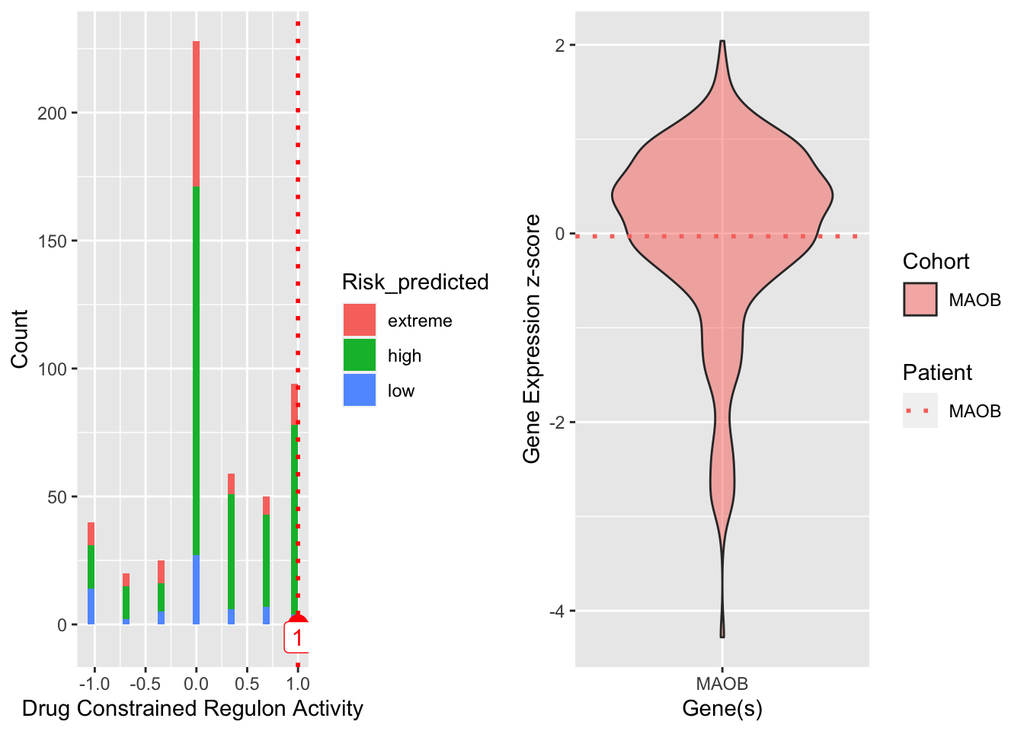

# 2. Target: SV2A

### Drugs

|  | Drug | Drug Action | Toxicity Class | Max GBM Phase | FDA Approved | Clinical Trials |
| --- | --- | --- | --- | --- | --- | --- |
| 1 | BRIVARACETAM | MODULATOR |  | 0 | TRUE | Clinical Trials |

### Model Evidence

**2** regulons containing the target(s), **SV2A** are overactive in this patient.

### Hallmarks Enrichment

None

### Literature Evidence

No additional evidence was found

### Glioblastoma Clinical Trials

No glioblastoma clinical trials were found for these drugs.

### Network Plots

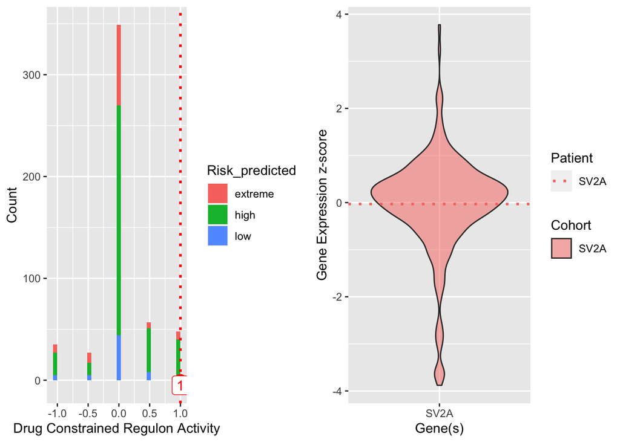

# 3. Target: ABL1

### Drugs

|  | Drug | Drug Action | Toxicity Class | Max GBM Phase | FDA Approved | Clinical Trials |
| --- | --- | --- | --- | --- | --- | --- |
| 1 | FLUMATINIB | INHIBITOR |  | 0 | TRUE | Clinical Trials |
| 2 | NILOTINIB HYDROCHLORIDE MONOHYDRATE | INHIBITOR |  | 0 | TRUE | Clinical Trials |
| 3 | REBASTINIB | INHIBITOR |  | 0 | TRUE | Clinical Trials |
| 4 | NILOTINIB | INHIBITOR | Cardiotoxicity | 0 | TRUE | Clinical Trials |
| 5 | ASCIMINIB | INHIBITOR |  | 0 | TRUE | Clinical Trials |

### Model Evidence

**5** regulons containing the target(s), **ABL1** are overactive in this patient.

### Hallmarks Enrichment

HALLMARK_MITOTIC_SPINDLE HALLMARK_G2M_CHECKPOINT

### Literature Evidence

|  | Gene | Evidence | Disease | Title | PMID | Year | Type |
| --- | --- | --- | --- | --- | --- | --- | --- |
| 1 | ABL1 | identify ABL as a crucial player for migration, invasion, proliferation, tumorigenic, and stem-cell like properties of GBM cells. Taken together, this work supports the notion that the oncogenic role … | GBM | Coordination of signalling networks and tumorigenic properties by ABL in glioblastoma cells | 27732969 | 2016 | Publication |
| 2 | ABL1 | Imatinib and nilotinib-induced tyrosine phosphorylation was dependent on expression of p130Cas and FAK activity and was independent of known imatinib targets including Abl, platelet derived growth fac… | GBM | Imatinib and Nilotinib increase glioblastoma cell invasion via Abl-independent stimulation of p130Cas and FAK signalling | 27293031 | 2016 | Publication |

### Glioblastoma Clinical Trials

No glioblastoma clinical trials were found for these drugs.

### Network Plots

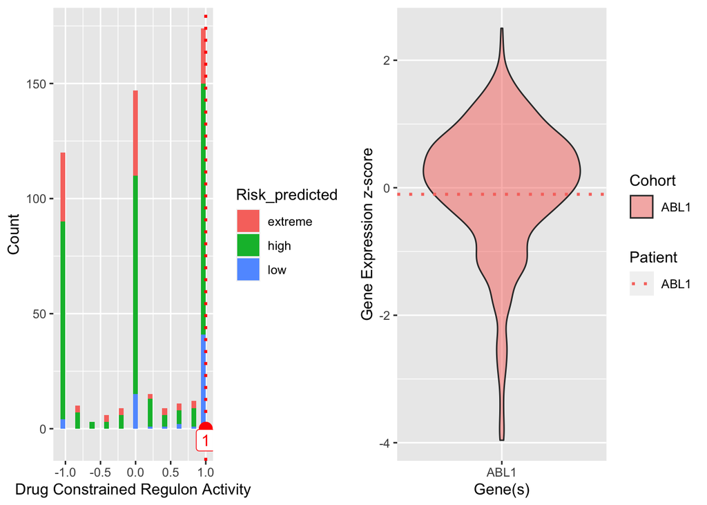

# 4. Target: MAPK10

### Drugs

|  | Drug | Drug Action | Toxicity Class | Max GBM Phase | FDA Approved | Clinical Trials |
| --- | --- | --- | --- | --- | --- | --- |
| 1 | TANZISERTIB | INHIBITOR |  | 0 | TRUE | Clinical Trials |
| 2 | BENTAMAPIMOD | INHIBITOR |  | 0 | TRUE | Clinical Trials |
| 3 | CC-401 | INHIBITOR |  | 0 | TRUE | Clinical Trials |

### Model Evidence

**2** regulons containing the target(s), **MAPK10** are overactive in this patient.

### Hallmarks Enrichment

None

### Literature Evidence

No additional evidence was found

### Glioblastoma Clinical Trials

No glioblastoma clinical trials were found for these drugs.

### Network Plots

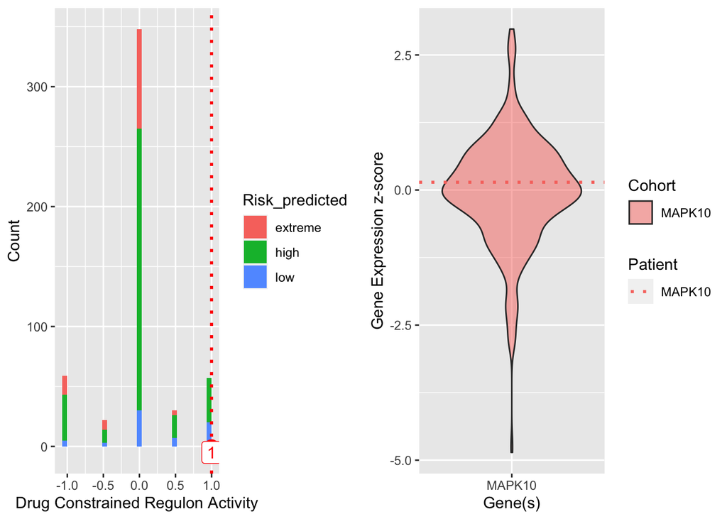

# 5. Target: RTN4

### Drugs

|  | Drug | Drug Action | Toxicity Class | Max GBM Phase | FDA Approved | Clinical Trials |
| --- | --- | --- | --- | --- | --- | --- |
| 1 | OZANEZUMAB | INHIBITOR |  | 0 | TRUE | Clinical Trials |
| 2 | ATINUMAB | INHIBITOR |  | 0 | TRUE | Clinical Trials |

### Model Evidence

**3** regulons containing the target(s), **RTN4** are overactive in this patient.

### Hallmarks Enrichment

None

### Literature Evidence

No additional evidence was found

### Glioblastoma Clinical Trials

No glioblastoma clinical trials were found for these drugs.

### Network Plots

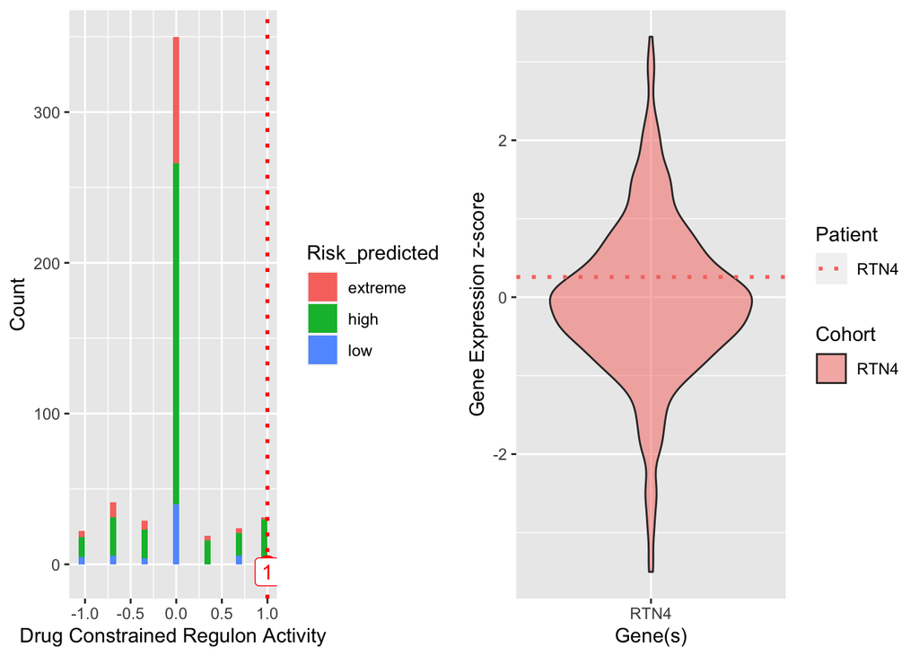

# 6. Target: NDUFA13

### Drugs

|  | Drug | Drug Action | Toxicity Class | Max GBM Phase | FDA Approved | Clinical Trials |
| --- | --- | --- | --- | --- | --- | --- |
| 1 | ME-344 | INHIBITOR |  | 0 | TRUE | Clinical Trials |

### Model Evidence

**5** regulons containing the target(s), **NDUFA13** are overactive in this patient.

### Hallmarks Enrichment

HALLMARK_OXIDATIVE_PHOSPHORYLATION HALLMARK_DNA_REPAIR HALLMARK_MYC_TARGETS_V1

### Literature Evidence

|  | Gene | Evidence | Disease | Title | PMID | Year | Type |
| --- | --- | --- | --- | --- | --- | --- | --- |
| 1 | NDUFA13 | In addition, recent relevant studies have also shown that some candidate tumor gene biomarkers were recognized as targets of glioma, and 4 genes (NDUFS5, NDUFA1, NDUFA13, and NDUFB8) of the candidate … | GBM | Gene biomarker prediction in glioma by integrating scRNA-seq data and gene regulatory network | 34863158 | 2021 | Publication |

### Glioblastoma Clinical Trials

No glioblastoma clinical trials were found for these drugs.

### Network Plots

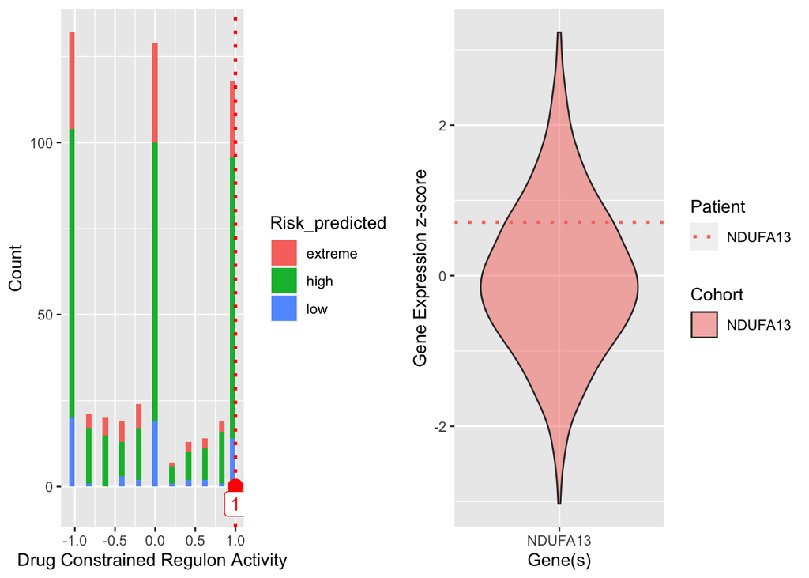

# 7. Target: TSG101

### Drugs

|  | Drug | Drug Action | Toxicity Class | Max GBM Phase | FDA Approved | Clinical Trials |
| --- | --- | --- | --- | --- | --- | --- |
| 1 | FGI-101-1A6 | INHIBITOR |  | 0 | TRUE | Clinical Trials |

### Model Evidence

**2** regulons containing the target(s), **TSG101** are overactive in this patient.

### Hallmarks Enrichment

HALLMARK_OXIDATIVE_PHOSPHORYLATION HALLMARK_DNA_REPAIR HALLMARK_MYC_TARGETS_V1

### Literature Evidence

|  | Gene | Evidence | Disease | Title | PMID | Year | Type |
| --- | --- | --- | --- | --- | --- | --- | --- |
| 1 | TSG101 | The functional studies showed that knockdown of TSG101 suppressed the proliferation, migration, and invasion of glioma cells, while overexpression of TSG101 facilitated them. Mechanistic studies indic… | GBM | TSG101 Promotes the Proliferation, Migration, and Invasion of Human Glioma Cells by Regulating the AKT/GSK3_/_-Catenin and RhoC/Cofilin Pathways | 33411238 | 2021 | Publication |

### Glioblastoma Clinical Trials

No glioblastoma clinical trials were found for these drugs.

### Network Plots

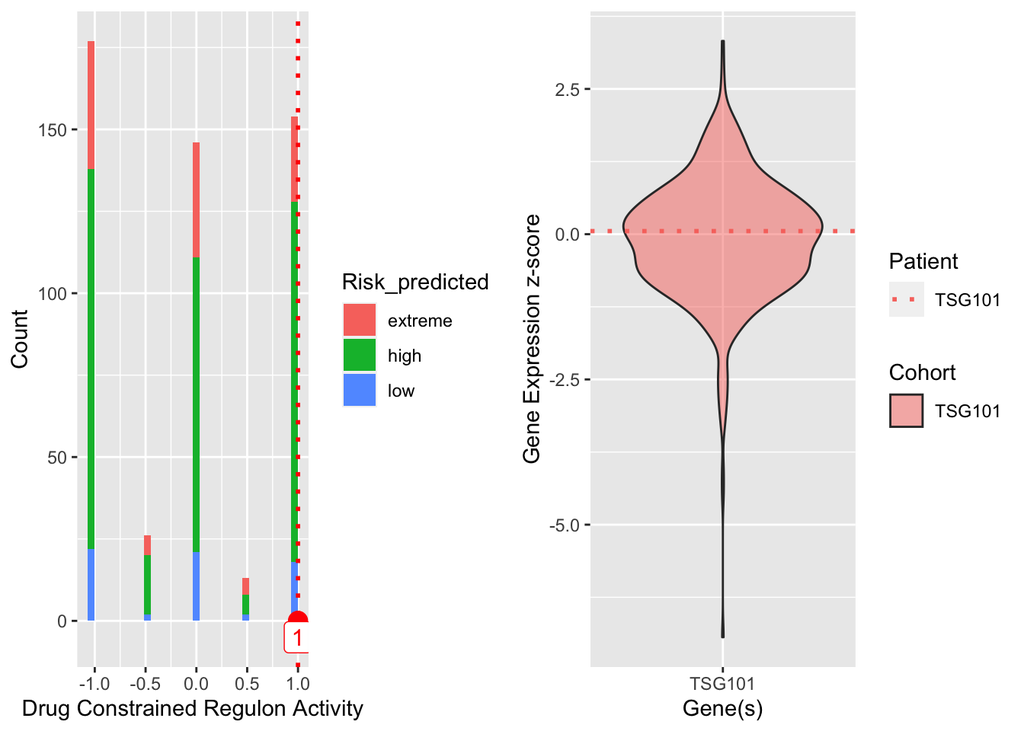

# 8. Target: SOD1

### Drugs

|  | Drug | Drug Action | Toxicity Class | Max GBM Phase | FDA Approved | Clinical Trials |
| --- | --- | --- | --- | --- | --- | --- |
| 1 | TOFERSEN | INHIBITOR |  | 0 | TRUE | Clinical Trials |

### Model Evidence

**6** regulons containing the target(s), **SOD1** are overactive in this patient.

### Hallmarks Enrichment

HALLMARK_OXIDATIVE_PHOSPHORYLATION HALLMARK_ADIPOGENESIS

### Literature Evidence

No additional evidence was found

### Glioblastoma Clinical Trials

No glioblastoma clinical trials were found for these drugs.

### Network Plots

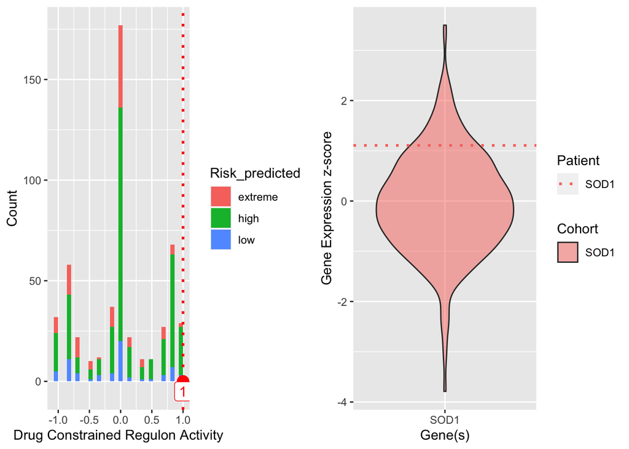

# 9. Target: ABAT

### Drugs

|  | Drug | Drug Action | Toxicity Class | Max GBM Phase | FDA Approved | Clinical Trials |
| --- | --- | --- | --- | --- | --- | --- |
| 1 | VIGABATRIN | INHIBITOR |  | 0 | TRUE | Clinical Trials |

### Model Evidence

**17** regulons containing the target(s), **ABAT** are overactive in this patient.

### Hallmarks Enrichment

None

### Literature Evidence

No additional evidence was found

### Glioblastoma Clinical Trials

No glioblastoma clinical trials were found for these drugs.

### Network Plots

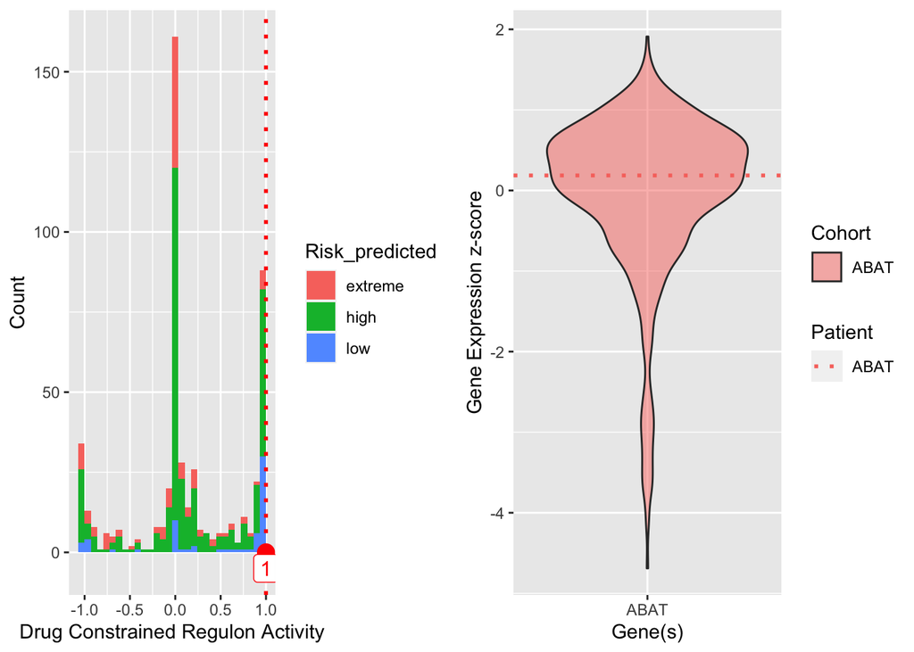

# 10. Target: NQO1

### Drugs

|  | Drug | Drug Action | Toxicity Class | Max GBM Phase | FDA Approved | Clinical Trials |
| --- | --- | --- | --- | --- | --- | --- |
| 1 | VATIQUINONE | MODULATOR |  | 0 | TRUE | Clinical Trials |

### Model Evidence

**2** regulons containing the target(s), **NQO1** are overactive in this patient.

### Hallmarks Enrichment

HALLMARK_REACTIVE_OXYGEN_SPECIES_PATHWAY

### Literature Evidence

No additional evidence was found

### Glioblastoma Clinical Trials

No glioblastoma clinical trials were found for these drugs.

### Network Plots

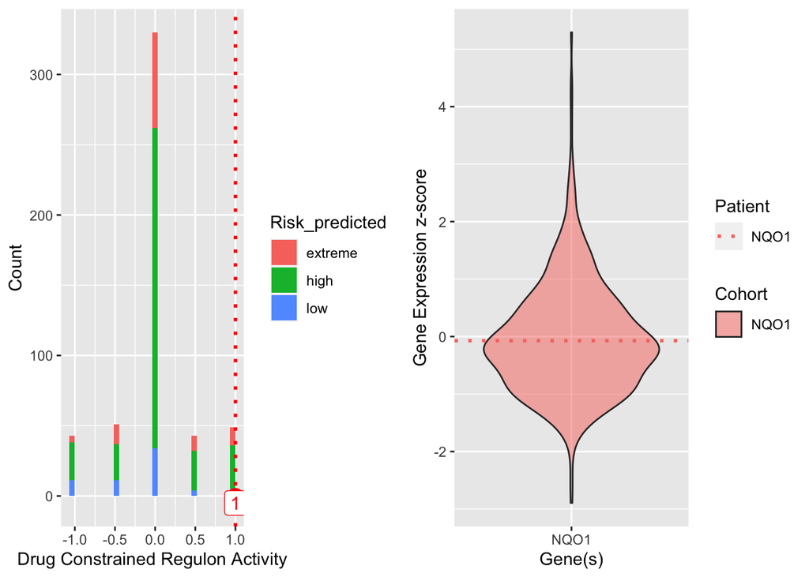

# 11. Target: F8

### Drugs

|  | Drug | Drug Action | Toxicity Class | Max GBM Phase | FDA Approved | Clinical Trials |
| --- | --- | --- | --- | --- | --- | --- |
| 1 | TB-402 | INHIBITOR |  | 0 | TRUE | Clinical Trials |

### Model Evidence

**2** regulons containing the target(s), **F8** are overactive in this patient.

### Hallmarks Enrichment

None

### Literature Evidence

No additional evidence was found

### Glioblastoma Clinical Trials

No glioblastoma clinical trials were found for these drugs.

### Network Plots

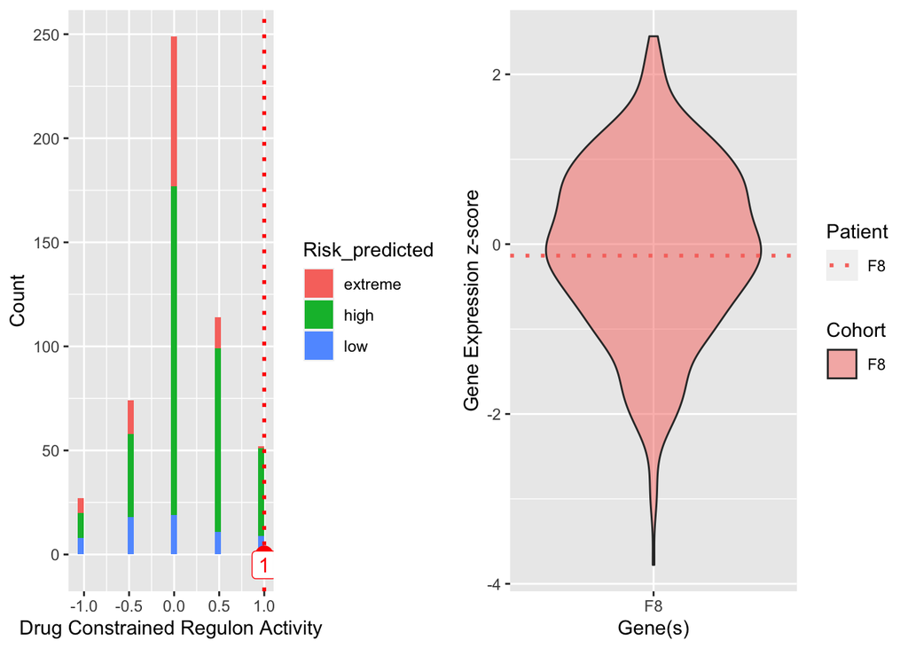

# 12. Target: TRPV4

### Drugs

|  | Drug | Drug Action | Toxicity Class | Max GBM Phase | FDA Approved | Clinical Trials |
| --- | --- | --- | --- | --- | --- | --- |
| 1 | GSK2798745 | ANTAGONIST |  | 0 | TRUE | Clinical Trials |

### Model Evidence

**1** regulons containing the target(s), **TRPV4** are overactive in this patient.

### Hallmarks Enrichment

None

### Literature Evidence

No additional evidence was found

### Glioblastoma Clinical Trials

No glioblastoma clinical trials were found for these drugs.

### Network Plots

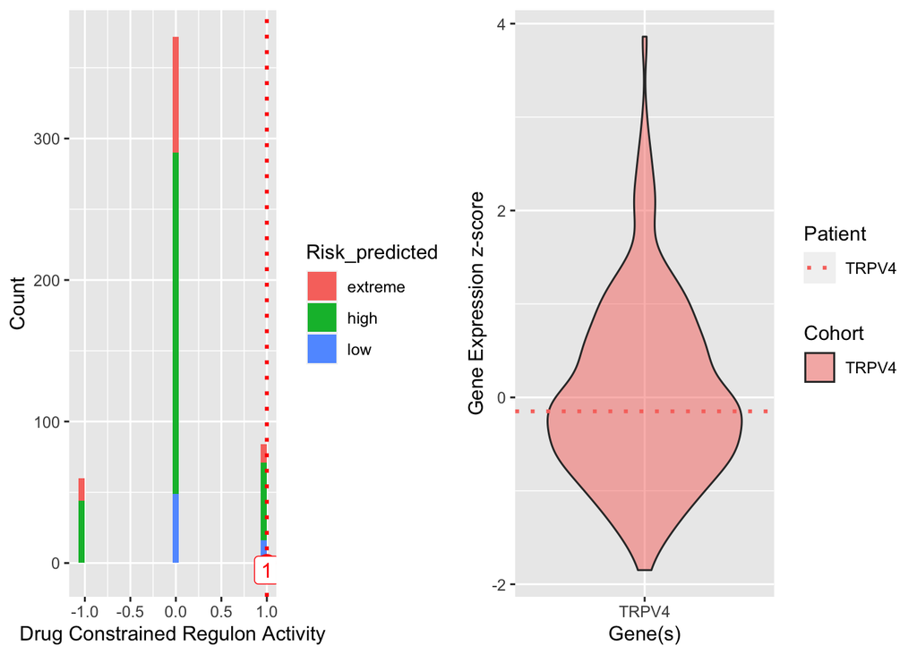

# 13. Target: MAPK1,MAPK3

### Drugs

|  | Drug | Drug Action | Toxicity Class | Max GBM Phase | FDA Approved | Clinical Trials |
| --- | --- | --- | --- | --- | --- | --- |
| 1 | MK-8353 | INHIBITOR |  | 0 | TRUE | Clinical Trials |
| 2 | ULIXERTINIB | INHIBITOR |  | 0 | TRUE | Clinical Trials |
| 3 | RAVOXERTINIB | INHIBITOR |  | 0 | TRUE | Clinical Trials |

### Model Evidence

**19** regulons containing the target(s), **MAPK1,MAPK3** are overactive in this patient.

### Hallmarks Enrichment

None

### Literature Evidence

No additional evidence was found

### Glioblastoma Clinical Trials

|  | NCT.Number | Title | Status | Interventions | Phases | First.Posted |
| --- | --- | --- | --- | --- | --- | --- |
| 1 | NCT04566393 | Expanded Access to Ulixertinib (BVD-523) in Patients With Advanced MAPK Pathway-Altered Malignancies | Available | Drug: Ulixertinib (BVD-523) |  | 28-Sep-20 |

### Network Plots

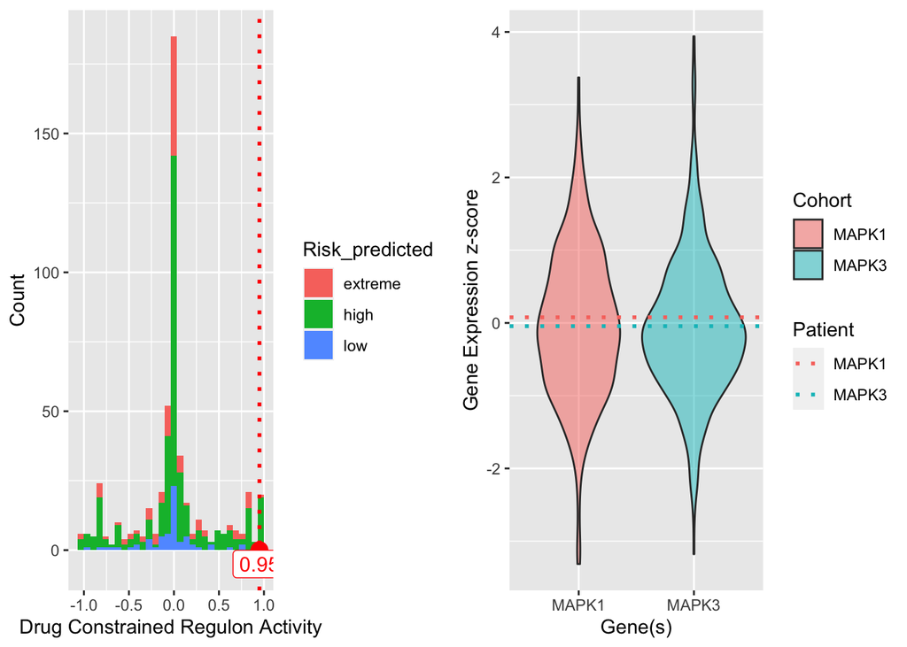

# 14. Target: RRM2

### Drugs

|  | Drug | Drug Action | Toxicity Class | Max GBM Phase | FDA Approved | Clinical Trials |
| --- | --- | --- | --- | --- | --- | --- |
| 1 | GALLIUM NITRATE | INHIBITOR |  | 0 | TRUE | Clinical Trials |
| 2 | GALLIUM NITRATE | SEQUESTERING AGENT |  | 0 | TRUE | Clinical Trials |

### Model Evidence

**12** regulons containing the target(s), **RRM2** are overactive in this patient.

### Hallmarks Enrichment

None

### Literature Evidence

|  | Gene | Evidence | Disease | Title | PMID | Year | Type |
| --- | --- | --- | --- | --- | --- | --- | --- |
| 1 | RRM2 | These findings indicated that RRM2 is a positive regulator of glioma progression which contributes to the migration and proliferation of glioma cells through ERK1/2 and AKT signalings and might be a n… | GBM | RRM2 is a potential prognostic biomarker with functional significance in glioma | 30745840 | 2019 | Publication |
| 2 | RRM2 | we show that treatment with a RRM2 inhibitor triapine reproduces the BRCA1-depletion GBM-repressive phenotypes and sensitizes GBM cells to PARP inhibition. We propose that GBM cells are addicted to th… | GBM | BRCA1-regulated RRM2 expression protects glioblastoma cells from endogenous replication stress and promotes tumorigenicity | 27845331 | 2016 | Publication |
| 3 | RRM2 | GBM cells were shown to rely on RRM2 during therapy causing RRM2-knockdown (KD) cells to be TMZ-sensitive.Ê | GBM | Ribonucleotide Reductase Regulatory Subunit M2 as a Driver of Glioblastoma TMZ-Resistance through Modulation of dNTP Production | 10.1101/2021.11.23.469785 | 2021 | Preprint |

### Glioblastoma Clinical Trials

No glioblastoma clinical trials were found for these drugs.

### Network Plots

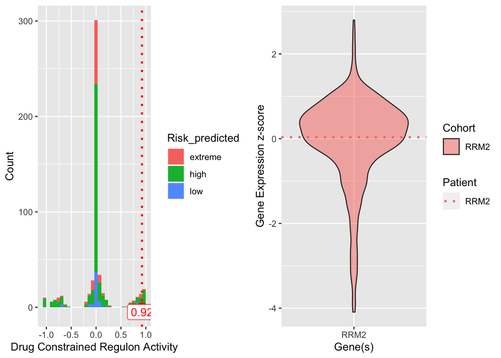

# 15. Target: HSPA8

### Drugs

|  | Drug | Drug Action | Toxicity Class | Max GBM Phase | FDA Approved | Clinical Trials |
| --- | --- | --- | --- | --- | --- | --- |
| 1 | FORIGERIMOD | INHIBITOR |  | 0 | TRUE | Clinical Trials |
| 2 | FORIGERIMOD ACETATE | INHIBITOR |  | 0 | TRUE | Clinical Trials |

### Model Evidence

**27** regulons containing the target(s), **HSPA8** are overactive in this patient.

### Hallmarks Enrichment

None

### Literature Evidence

No additional evidence was found

### Glioblastoma Clinical Trials

No glioblastoma clinical trials were found for these drugs.

### Network Plots

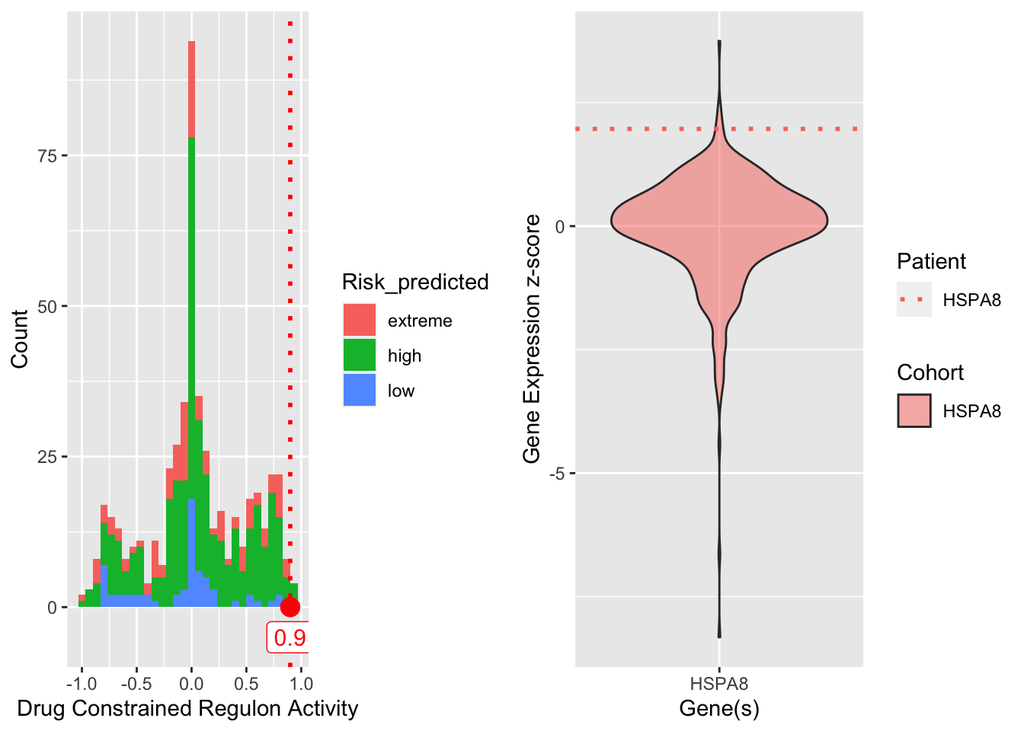

# 16. Target: SLC6A9

### Drugs

|  | Drug | Drug Action | Toxicity Class | Max GBM Phase | FDA Approved | Clinical Trials |
| --- | --- | --- | --- | --- | --- | --- |
| 1 | BITOPERTIN | INHIBITOR |  | 0 | TRUE | Clinical Trials |

### Model Evidence

**13** regulons containing the target(s), **SLC6A9** are overactive in this patient.

### Hallmarks Enrichment

None

### Literature Evidence

No additional evidence was found

### Glioblastoma Clinical Trials

No glioblastoma clinical trials were found for these drugs.

### Network Plots

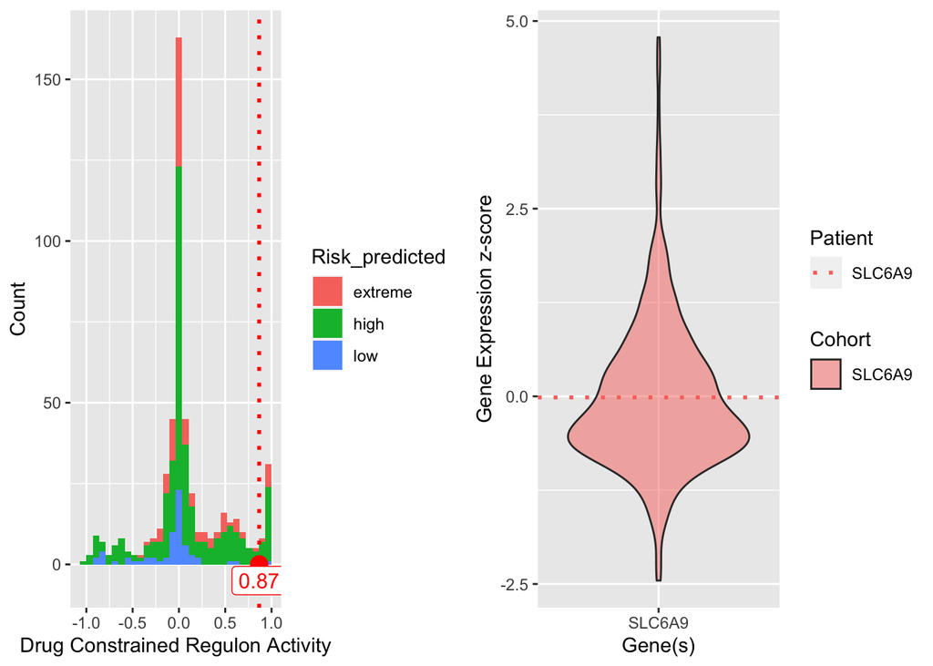

# 17. Target: GSR

### Drugs

|  | Drug | Drug Action | Toxicity Class | Max GBM Phase | FDA Approved | Clinical Trials |
| --- | --- | --- | --- | --- | --- | --- |
| 1 | OXIGLUTATIONE | OTHER |  | 0 | TRUE | Clinical Trials |

### Model Evidence

**6** regulons containing the target(s), **GSR** are overactive in this patient.

### Hallmarks Enrichment

None

### Literature Evidence

|  | Gene | Evidence | Disease | Title | PMID | Year | Type |
| --- | --- | --- | --- | --- | --- | --- | --- |
| 1 | GSR | Carmustine implantation in resection cavity provides survival benefit for GBM patients, and it may be a promising supplement to standard therapeutic protocol by offering a bridge between surgical rese… | GBM | Carmustine as a Supplementary Therapeutic Option for Glioblastoma: A Systematic Review and Meta-Analysis | 33041980 | 2020 | Publication |
| 2 | GSR | The expression of glutathione reductase (GSR), was higher in TMZ-resistant cells than in sensitive cells. Silencing GSR in drug-resistant cells improved the sensitivity of cells to TMZ or cisplatin. | GBM | Glutathione reductase mediates drug resistance in glioblastoma cells by regulating redox homeostasis | 29105080 | 2018 | Publication |
| 3 | GSR | We showed that upon TMZ treatment there is an induction of the nuclear factor erythroid 2-related factor 2 (NRF2), which is the main antioxidant transcription factor regulator in human cells. This is … | GBM | NRF2 and glutathione are key resistance mediators to temozolomide in glioma and melanoma cells | 27344172 | 2016 | Publication |
| 4 | GSR | The present disclosure teaches that glioma cells are dependent on system Xc for cystine uptake. Pharmacological inhibition of system Xc causes a rapid depletion of intracellular glutathione, resulting… | GBM | Method for treating glioma | WO2006049957A2 | 2005 | Patent |

### Glioblastoma Clinical Trials

No glioblastoma clinical trials were found for these drugs.

### Network Plots

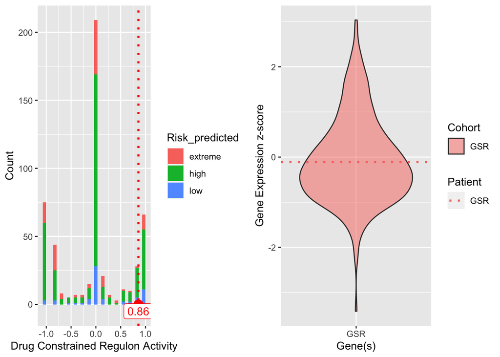

# 18. Target: ACVR2B

### Drugs

|  | Drug | Drug Action | Toxicity Class | Max GBM Phase | FDA Approved | Clinical Trials |
| --- | --- | --- | --- | --- | --- | --- |
| 1 | BIMAGRUMAB | ANTAGONIST |  | 0 | TRUE | Clinical Trials |

### Model Evidence

**5** regulons containing the target(s), **ACVR2B** are overactive in this patient.

### Hallmarks Enrichment

HALLMARK_MITOTIC_SPINDLE HALLMARK_G2M_CHECKPOINT

### Literature Evidence

No additional evidence was found

### Glioblastoma Clinical Trials

No glioblastoma clinical trials were found for these drugs.

### Network Plots

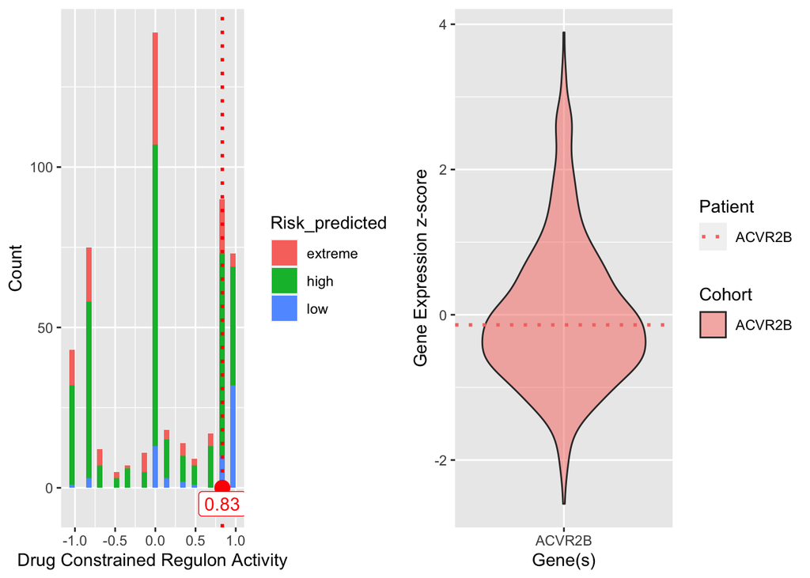